# exercise-choosing-plot-types-and-custom-styles

**This notebook is an exercise in the [Data Visualization](https://www.kaggle.com/learn/data-visualization) course. You can reference the tutorial at [this link](https://www.kaggle.com/alexisbcook/choosing-plot-types-and-custom-styles).**

In this exercise, you'll explore different chart styles, to see which color combinations and fonts you like best!

## Setup

Run the next cell to import and configure the Python libraries that you need to complete the exercise.

```python
import pandas as pd
pd.plotting.register_matplotlib_converters()
import matplotlib.pyplot as plt
%matplotlib inline
import seaborn as sns
print("Setup Complete")
```

```
Setup Complete
```

The questions below will give you feedback on your work. Run the following cell to set up our feedback system.

```python
# Set up code checking
import os
if not os.path.exists("../input/spotify.csv"):
    os.symlink("../input/data-for-datavis/spotify.csv", "../input/spotify.csv")
from learntools.core import binder
binder.bind(globals())
from learntools.data_viz_to_coder.ex6 import *
print("Setup Complete")
```

```
Setup Complete
```

You'll work with a chart from the previous tutorial. Run the next cell to load the data.

```python
# Path of the file to read
spotify_filepath = "../input/spotify.csv"

# Read the file into a variable spotify_data
spotify_data = pd.read_csv(spotify_filepath, index_col="Date", parse_dates=True)
```

# Try out seaborn styles

Run the command below to try out the `"dark"` theme.

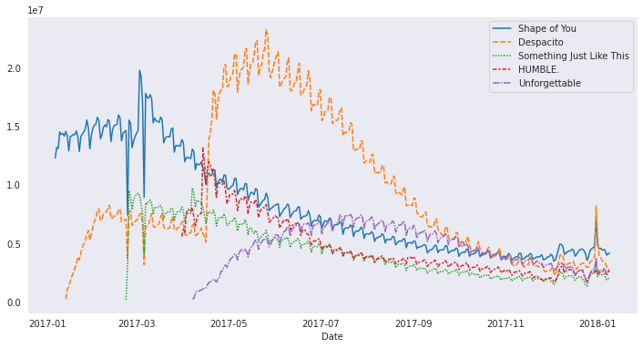

```python
# Change the style of the figure
# darkgrid whitegrid dark white ticks
sns.set_style("dark")

# Line chart
plt.figure(figsize=(12,6))
sns.lineplot(data=spotify_data)

# Mark the exercise complete after the code cell is run
step_1.check()
```

Now, try out different themes by amending the first line of code and running the code cell again. Remember the list of available themes:

- `"darkgrid"`
- `"whitegrid"`
- `"dark"`
- `"white"`
- `"ticks"`

This notebook is your playground -- feel free to experiment as little or as much you wish here! The exercise is marked as complete after you run every code cell in the notebook at least once.

## Keep going

Learn about how to select and visualize your own datasets in the **[next tutorial](https://www.kaggle.com/alexisbcook/final-project)**!

*Have questions or comments? Visit the [Learn Discussion forum](https://www.kaggle.com/learn-forum/161291) to chat with other Learners.*